# Travel Package Purchase Prediction

### Hyperparameter Tuning for Random Forest Classifier

```python
# Choose the type of classifier.
rf_tuned = RandomForestClassifier(class_weight={0:0.18,1:0.82},random_state=1,oob_score=True,bootstrap=True)

parameters = {
                'max_depth': list(np.arange(5,30,5)) + [None],
                'max_features': ['sqrt','log2',None],
                'min_samples_leaf': np.arange(1,15,5),
                'min_samples_split': np.arange(2, 20, 5),
                'n_estimators': np.arange(10,110,10)}


# Type of scoring used to compare parameter combinations
scorer = metrics.make_scorer(metrics.f1_score)

# Run the grid search
grid_obj = GridSearchCV(rf_tuned, parameters, scoring=scorer, cv=5,n_jobs=-1)
grid_obj = grid_obj.fit(X_train, y_train)

# Set the clf to the best combination of parameters
rf_tuned = grid_obj.best_estimator_

# Fit the best algorithm to the data.
rf_tuned.fit(X_train, y_train)
```

```
RandomForestClassifier(class_weight={0: 0.18, 1: 0.82}, max_depth=20,
                       max_features=None, min_samples_split=7, n_estimators=50,
                       oob_score=True, random_state=1)
```

```
Training performance:
    Accuracy    Recall  Precision        F1
0  0.993652  0.998405    0.96904  0.983504
Testing performance:
    Accuracy    Recall  Precision      F1
0  0.923131  0.732342    0.84188  0.7833
```

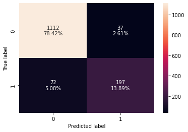

```python
#Calculating different metrics
rf_tuned_model_train_perf=model_performance_classification_sklearn(rf_tuned,X_train,y_train)
print("Training performance:\n",rf_tuned_model_train_perf)
rf_tuned_model_test_perf=model_performance_classification_sklearn(rf_tuned,X_test,y_test)
print("Testing performance:\n",rf_tuned_model_test_perf)

#Creating confusion matrix
confusion_matrix_sklearn(rf_tuned,X_test,y_test)
```

HyperParameter tuning did help to reduce overfitting. The Recall also improved, overall the model performace improved.

### Bagging Classifier

```
   Accuracy    Recall  Precision        F1
0   0.99607  0.979266        1.0  0.989525
   Accuracy    Recall  Precision        F1
0  0.911142  0.613383   0.882353  0.723684
```

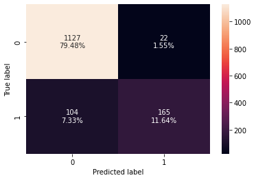

```python
#Fitting the model
bagging_classifier = BaggingClassifier(random_state=1)
bagging_classifier.fit(X_train,y_train)

#Calculating different metrics
bagging_classifier_model_train_perf=model_performance_classification_sklearn(bagging_classifier,X_train,y_train)
print(bagging_classifier_model_train_perf)
bagging_classifier_model_test_perf=model_performance_classification_sklearn(bagging_classifier,X_test,y_test)
print(bagging_classifier_model_test_perf)

#Creating confusion matrix
confusion_matrix_sklearn(bagging_classifier,X_test,y_test)
```

The Bagging Classifier also seems to be overfitting, The performance is not that good, it gives a Recall score of 0.61.

### Hyperparameter tuning for Bagging Classifier

```python
# Choose the type of classifier.
bagging_estimator_tuned = BaggingClassifier(random_state=1)

# Grid of parameters to choose from
parameters = {'max_samples': [0.7,0.8,0.9,1],
              'max_features': [0.7,0.8,0.9,1],
              'n_estimators' : [10,20,30,40,50],
             }

# Type of scoring used to compare parameter combinations
scorer = metrics.make_scorer(metrics.f1_score)

# Run the grid search
grid_obj = GridSearchCV(bagging_estimator_tuned, parameters, scoring=scorer,cv=5)
grid_obj = grid_obj.fit(X_train, y_train)

# Set the clf to the best combination of parameters
bagging_estimator_tuned = grid_obj.best_estimator_

# Fit the best algorithm to the data.
bagging_estimator_tuned.fit(X_train, y_train)
```

```
BaggingClassifier(max_features=0.8, max_samples=0.9, n_estimators=40,
                  random_state=1)
```

```
   Accuracy   Recall  Precision        F1
0  0.999395  0.99681        1.0  0.998403
   Accuracy    Recall  Precision        F1
0  0.923836  0.643123   0.935135  0.762115
```

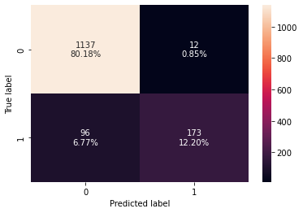

```python
#Calculating different metrics
bagging_estimator_tuned_model_train_perf=model_performance_classification_sklearn(bagging_estimator_tuned,X_train,y_train)
print(bagging_estimator_tuned_model_train_perf)
bagging_estimator_tuned_model_test_perf=model_performance_classification_sklearn(bagging_estimator_tuned,X_test,y_test)
print(bagging_estimator_tuned_model_test_perf)

#Creating confusion matrix
confusion_matrix_sklearn(bagging_estimator_tuned,X_test,y_test)
```

The Precision with this model is very good but the Recall is only 0.64. The overall F1 sccore is 0.76

### AdaBoost Classifier

```
   Accuracy    Recall  Precision        F1
0   0.85127  0.358852   0.714286  0.477707
   Accuracy    Recall  Precision        F1
0  0.841326  0.301115   0.686441  0.418605
```

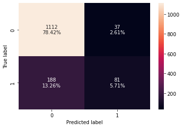

```python
#Fitting the model
ab_classifier = AdaBoostClassifier(random_state=1)
ab_classifier.fit(X_train,y_train)

#Calculating different metrics
ab_classifier_model_train_perf=model_performance_classification_sklearn(ab_classifier,X_train,y_train)
print(ab_classifier_model_train_perf)
ab_classifier_model_test_perf=model_performance_classification_sklearn(ab_classifier,X_test,y_test)
print(ab_classifier_model_test_perf)

#Creating confusion matrix
confusion_matrix_sklearn(ab_classifier,X_test,y_test)
```

This model is not overfitting,. however its performance is not good, the Recall is only 0.3. lets see if hyperparameter tuning will help

### Hyperparameter tuning AdaBoost Classifier

```python
# Choose the type of classifier.
abc_tuned = AdaBoostClassifier(random_state=1)

# Grid of parameters to choose from
parameters = {
    #Let's try different max_depth for base_estimator
    "base_estimator":[DecisionTreeClassifier(max_depth=1),DecisionTreeClassifier(max_depth=2),
                      DecisionTreeClassifier(max_depth=3)],
    "n_estimators": np.arange(10,110,10),
    "learning_rate":np.arange(0.1,2,0.1)
}

# Type of scoring used to compare parameter  combinations
scorer = metrics.make_scorer(metrics.f1_score)

# Run the grid search
grid_obj = GridSearchCV(abc_tuned, parameters, scoring=scorer,cv=5)
grid_obj = grid_obj.fit(X_train, y_train)

# Set the clf to the best combination of parameters
abc_tuned = grid_obj.best_estimator_

# Fit the best algorithm to the data.
abc_tuned.fit(X_train, y_train)
```

```
AdaBoostClassifier(base_estimator=DecisionTreeClassifier(max_depth=3),
                   learning_rate=0.8, n_estimators=100, random_state=1)
```

```
   Accuracy    Recall  Precision        F1
0  0.986397  0.939394   0.988255  0.963205
   Accuracy   Recall  Precision        F1
0  0.880818  0.60223   0.723214  0.657201
```

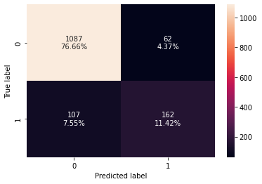

```python
#Calculating different metrics
abc_tuned_model_train_perf=model_performance_classification_sklearn(abc_tuned,X_train,y_train)
print(abc_tuned_model_train_perf)
abc_tuned_model_test_perf=model_performance_classification_sklearn(abc_tuned,X_test,y_test)
print(abc_tuned_model_test_perf)

#Creating confusion matrix
confusion_matrix_sklearn(abc_tuned,X_test,y_test)
```

The hyperparameter tuning caused the model to overfit, the recall improved.

### Gradient Boosting Classifier

```
Training performance:
    Accuracy    Recall  Precision        F1
0  0.892987  0.499203   0.886686  0.638776
Testing performance:
    Accuracy    Recall  Precision        F1
0  0.875882  0.412639   0.860465  0.557789
```

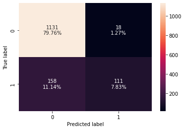

```python
#Fitting the model
gb_classifier = GradientBoostingClassifier(random_state=1)
gb_classifier.fit(X_train,y_train)

#Calculating different metrics
gb_classifier_model_train_perf=model_performance_classification_sklearn(gb_classifier,X_train,y_train)
print("Training performance:\n",gb_classifier_model_train_perf)
gb_classifier_model_test_perf=model_performance_classification_sklearn(gb_classifier,X_test,y_test)
print("Testing performance:\n",gb_classifier_model_test_perf)

#Creating confusion matrix
confusion_matrix_sklearn(gb_classifier,X_test,y_test)
```

The model is not over fitting, the Recall is not good at 0.41. lets see if hypertuning will help.

### Hyperparameter tuning Gradient Boosting Classifier

```python
# Choose the type of classifier.
gbc_tuned = GradientBoostingClassifier(init=AdaBoostClassifier(random_state=1),random_state=1)

# Grid of parameters to choose from
parameters = {
    "n_estimators": [100,150,200,250],
    "subsample":[0.8,0.9,1],
    "max_features":[0.7,0.8,0.9,1]
}

# Type of scoring used to compare parameter combinations
scorer = metrics.make_scorer(metrics.f1_score)

# Run the grid search
grid_obj = GridSearchCV(gbc_tuned, parameters, scoring=scorer,cv=5)
grid_obj = grid_obj.fit(X_train, y_train)

# Set the clf to the best combination of parameters
gbc_tuned = grid_obj.best_estimator_

# Fit the best algorithm to the data.
gbc_tuned.fit(X_train, y_train)
```

```
GradientBoostingClassifier(init=AdaBoostClassifier(random_state=1),
                           max_features=0.8, n_estimators=250, random_state=1,
                           subsample=0.8)
```

```
Training performance:
    Accuracy    Recall  Precision        F1
0  0.929262  0.666667   0.943567  0.781308
Testing performance:
    Accuracy    Recall  Precision        F1
0  0.875176  0.483271    0.77381  0.594966
```

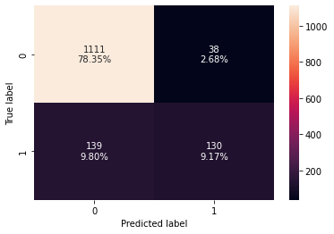

```python
#Calculating different metrics
gbc_tuned_model_train_perf=model_performance_classification_sklearn(gbc_tuned,X_train,y_train)
print("Training performance:\n",gbc_tuned_model_train_perf)
gbc_tuned_model_test_perf=model_performance_classification_sklearn(gbc_tuned,X_test,y_test)
print("Testing performance:\n",gbc_tuned_model_test_perf)

#Creating confusion matrix
confusion_matrix_sklearn(gbc_tuned,X_test,y_test)
```

Hyperparameter tuning made the Recall improve very slightly with 0.48

### XGB Classifier

```
Training performance:
    Accuracy  Recall  Precision   F1
0       1.0     1.0        1.0  1.0
Testing performance:
    Accuracy   Recall  Precision        F1
0  0.930889  0.70632   0.909091  0.794979
```

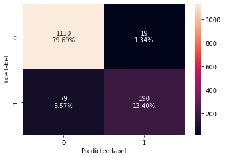

```python
#Fitting the model
xgb_classifier = XGBClassifier(random_state=1, eval_metric='logloss')
xgb_classifier.fit(X_train,y_train)

#Calculating different metrics
xgb_classifier_model_train_perf=model_performance_classification_sklearn(xgb_classifier,X_train,y_train)
print("Training performance:\n",xgb_classifier_model_train_perf)
xgb_classifier_model_test_perf=model_performance_classification_sklearn(xgb_classifier,X_test,y_test)
print("Testing performance:\n",xgb_classifier_model_test_perf)

#Creating confusion matrix
confusion_matrix_sklearn(xgb_classifier,X_test,y_test)
```

The model is over fitting, however the model performance improved with Recall score of 0.7

### HyperParameter Tuning with XGB

```python
# Choose the type of classifier.
xgb_tuned = XGBClassifier(random_state=1, eval_metric='logloss')

# Grid of parameters to choose from
parameters = {
    "n_estimators": [10,30,50],
    "scale_pos_weight":[1,2,5],
    "subsample":[0.7,0.9,1],
    "learning_rate":[0.05, 0.1,0.2],
    "colsample_bytree":[0.7,0.9,1],
    "colsample_bylevel":[0.5,0.7,1]
}

# Type of scoring used to compare parameter combinations
scorer = metrics.make_scorer(metrics.f1_score)

# Run the grid search
grid_obj = GridSearchCV(xgb_tuned, parameters,scoring=scorer,cv=5)
grid_obj = grid_obj.fit(X_train, y_train)

# Set the clf to the best combination of parameters
xgb_tuned = grid_obj.best_estimator_

# Fit the best algorithm to the data.
xgb_tuned.fit(X_train, y_train)
```

```
XGBClassifier(base_score=0.5, booster='gbtree', colsample_bylevel=1,
              colsample_bynode=1, colsample_bytree=1, enable_categorical=False,
              eval_metric='logloss', gamma=0, gpu_id=-1, importance_type=None,
              interaction_constraints='', learning_rate=0.2, max_delta_step=0,
              max_depth=6, min_child_weight=1, missing=nan,
              monotone_constraints='()', n_estimators=50, n_jobs=8,
              num_parallel_tree=1, predictor='auto', random_state=1,
              reg_alpha=0, reg_lambda=1, scale_pos_weight=5, subsample=1,
              tree_method='exact', validate_parameters=1, verbosity=None)
```

```
Training performance:
    Accuracy    Recall  Precision        F1
0  0.978839  0.992026   0.905386  0.946728
Testing performance:
    Accuracy    Recall  Precision        F1
0  0.905501  0.806691   0.725753  0.764085
```

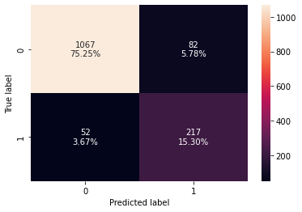

```python
#Calculating different metrics
xgb_tuned_model_train_perf=model_performance_classification_sklearn(xgb_tuned,X_train,y_train)
print("Training performance:\n",xgb_tuned_model_train_perf)
xgb_tuned_model_test_perf=model_performance_classification_sklearn(xgb_tuned,X_test,y_test)
print("Testing performance:\n",xgb_tuned_model_test_perf)

#Creating confusion matrix
confusion_matrix_sklearn(xgb_tuned,X_test,y_test)
```

Hyperparameter tuning helped with overfitting, it also improved the performance, the Recall is 0.81

### Stacking Classifier

```python
estimators = [('Random Forest',rf_tuned), ('Gradient Boosting',gbc_tuned), ('Decision Tree',dtree_estimator)]

final_estimator = xgb_tuned

stacking_classifier= StackingClassifier(estimators=estimators,final_estimator=final_estimator)

stacking_classifier.fit(X_train,y_train)
```

```
StackingClassifier(estimators=[('Random Forest',
                                RandomForestClassifier(class_weight={0: 0.18,
                                                                     1: 0.82},
                                                       max_depth=20,
                                                       max_features=None,
                                                       min_samples_split=7,
                                                       n_estimators=50,
                                                       oob_score=True,
                                                       random_state=1)),
                               ('Gradient Boosting',
                                GradientBoostingClassifier(init=AdaBoostClassifier(random_state=1),
                                                           max_features=0.8,
                                                           n_estimators=250,
                                                           random_state=1,
                                                           subsample=0.8)),...
                                                 gpu_id=-1,
                                                 importance_type=None,
                                                 interaction_constraints='',
                                                 learning_rate=0.2,
                                                 max_delta_step=0, max_depth=6,
                                                 min_child_weight=1,
                                                 missing=nan,
                                                 monotone_constraints='()',
                                                 n_estimators=50, n_jobs=8,
                                                 num_parallel_tree=1,
                                                 predictor='auto',
                                                 random_state=1, reg_alpha=0,
                                                 reg_lambda=1,
                                                 scale_pos_weight=5,
                                                 subsample=1,
                                                 tree_method='exact',
                                                 validate_parameters=1,
                                                 verbosity=None))
```

```
Training performance:
    Accuracy  Recall  Precision        F1
0  0.977932     1.0   0.895714  0.944989
Testing performance:
    Accuracy    Recall  Precision        F1
0  0.906911  0.903346   0.696275  0.786408
```

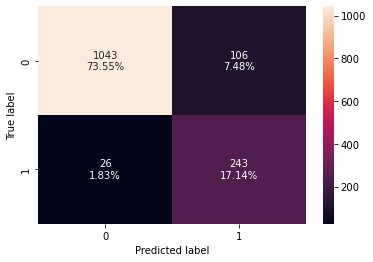

```python
#Calculating different metrics
stacking_classifier_model_train_perf=model_performance_classification_sklearn(stacking_classifier,X_train,y_train)
print("Training performance:\n",stacking_classifier_model_train_perf)
stacking_classifier_model_test_perf=model_performance_classification_sklearn(stacking_classifier,X_test,y_test)
print("Testing performance:\n",stacking_classifier_model_test_perf)

#Creating confusion matrix
confusion_matrix_sklearn(stacking_classifier,X_test,y_test)
```

There is some overfitting but the Recall has improved with 0.9 and the overall model performance has improved.

## LightGBM

```python
#!pip install lightgbm
import lightgbm as lgb

#LightGBM can use categorical features as input directly. It doesn’t need to convert to one-hot encoding,
#and is much faster than one-hot encoding (about 8x speed-up).
#Also we will not be imputing the null values as LightGBM takes care of the null values

#Loading train and test data again without one-hot encoding
XL = data.drop(["ProdTaken"], axis=1)
YL = data["ProdTaken"]

# Splitting data in train and test sets
XL_train, XL_test, yl_train, yl_test = train_test_split(
    XL, YL, test_size=0.30, random_state=1, stratify=YL
)
lgb_model = lgb.LGBMClassifier(learning_rate=0.09,max_depth=-5,random_state=42)
lgb_model.fit(XL_train,yl_train,eval_set=[(XL_test,yl_test),(XL_train,yl_train)],
          verbose=20,eval_metric='logloss')
```

```
[20]	training's binary_logloss: 0.274634	valid_0's binary_logloss: 0.326048
[40]	training's binary_logloss: 0.202768	valid_0's binary_logloss: 0.281482
[60]	training's binary_logloss: 0.15721	valid_0's binary_logloss: 0.25721
[80]	training's binary_logloss: 0.126587	valid_0's binary_logloss: 0.240373
[100]	training's binary_logloss: 0.10176	valid_0's binary_logloss: 0.222271
```

```
LGBMClassifier(learning_rate=0.09, max_depth=-5, random_state=42)
```

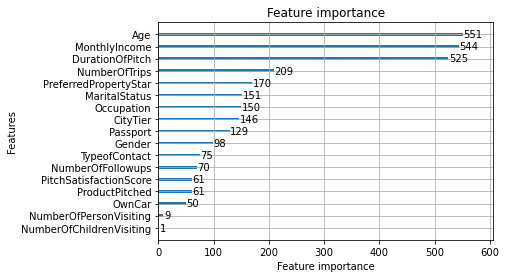

```python
lgb.plot_importance(lgb_model)
```

For LightGBM the top important features are Age, MonthlyIncome, DurationOfPitch, and NumberOfTrips.

```
Training performance:
    Accuracy    Recall  Precision        F1
0  0.987606  0.939394   0.994932  0.966366
Testing performance:
    Accuracy   Recall  Precision        F1
0  0.913258  0.60223   0.910112  0.724832
```

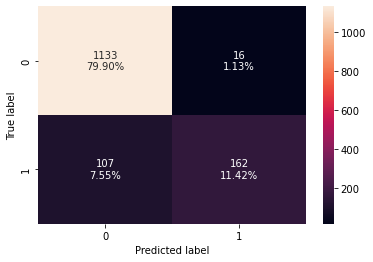

```python
#Calculating different metrics
lgb_model_train_perf=model_performance_classification_sklearn(lgb_model,X_train,y_train)
print("Training performance:\n",lgb_model_train_perf)
lgb_model_test_perf=model_performance_classification_sklearn(lgb_model,X_test,y_test)
print("Testing performance:\n",lgb_model_test_perf)

#Creating confusion matrix
confusion_matrix_sklearn(lgb_model,X_test,y_test)
```

The model is slightly over fitting, the performance is not that good as the Recall is only 0.6, However, the Precision score is really good.

### Comparing all models

```python
# training performance comparison

models_train_comp_df = pd.concat(
    [d_tree_model_train_perf.T,dtree_estimator_model_train_perf.T,rf_estimator_model_train_perf.T,rf_tuned_model_train_perf.T,
     bagging_classifier_model_train_perf.T,bagging_estimator_tuned_model_train_perf.T,ab_classifier_model_train_perf.T,
     abc_tuned_model_train_perf.T,gb_classifier_model_train_perf.T,gbc_tuned_model_train_perf.T,xgb_classifier_model_train_perf.T,
    xgb_tuned_model_train_perf.T,stacking_classifier_model_train_perf.T, lgb_model_train_perf.T],
    axis=1,
)
models_train_comp_df.columns = [
    "Decision Tree",
    "Decision Tree Estimator",
    "Random Forest Estimator",
    "Random Forest Tuned",
    "Bagging Classifier",
    "Bagging Estimator Tuned",
    "Adaboost Classifier",
    "Adabosst Classifier Tuned",
    "Gradient Boost Classifier",
    "Gradient Boost Classifier Tuned",
    "XGBoost Classifier",
    "XGBoost Classifier Tuned",
    "Stacking Classifier",
    "LightGBM Classifier"]
print("Training performance comparison:")
models_train_comp_df
```

```
Training performance comparison:
```

|  | Decision Tree | Decision Tree Estimator | Random Forest Estimator | Random Forest Tuned | Bagging Classifier | Bagging Estimator Tuned | Adaboost Classifier | Adabosst Classifier Tuned | Gradient Boost Classifier | Gradient Boost Classifier Tuned | XGBoost Classifier | XGBoost Classifier Tuned | Stacking Classifier | LightGBM Classifier |
| --- | --- | --- | --- | --- | --- | --- | --- | --- | --- | --- | --- | --- | --- | --- |
| Accuracy | 1.0 | 0.802600 | 1.0 | 0.993652 | 0.996070 | 0.999395 | 0.851270 | 0.986397 | 0.892987 | 0.929262 | 1.0 | 0.978839 | 0.977932 | 0.987606 |
| Recall | 1.0 | 0.695375 | 1.0 | 0.998405 | 0.979266 | 0.996810 | 0.358852 | 0.939394 | 0.499203 | 0.666667 | 1.0 | 0.992026 | 1.000000 | 0.939394 |
| Precision | 1.0 | 0.485523 | 1.0 | 0.969040 | 1.000000 | 1.000000 | 0.714286 | 0.988255 | 0.886686 | 0.943567 | 1.0 | 0.905386 | 0.895714 | 0.994932 |
| F1 | 1.0 | 0.571803 | 1.0 | 0.983504 | 0.989525 | 0.998403 | 0.477707 | 0.963205 | 0.638776 | 0.781308 | 1.0 | 0.946728 | 0.944989 | 0.966366 |

```python
# testing performance comparison

models_test_comp_df = pd.concat(
    [d_tree_model_test_perf.T,dtree_estimator_model_test_perf.T,rf_estimator_model_test_perf.T,rf_tuned_model_test_perf.T,
     bagging_classifier_model_test_perf.T,bagging_estimator_tuned_model_test_perf.T,ab_classifier_model_test_perf.T,
     abc_tuned_model_test_perf.T,gb_classifier_model_test_perf.T,gbc_tuned_model_test_perf.T,xgb_classifier_model_test_perf.T,
    xgb_tuned_model_test_perf.T,stacking_classifier_model_test_perf.T, lgb_model_test_perf.T],
    axis=1,
)
models_test_comp_df.columns = [
    "Decision Tree",
    "Decision Tree Estimator",
    "Random Forest Estimator",
    "Random Forest Tuned",
    "Bagging Classifier",
    "Bagging Estimator Tuned",
    "Adaboost Classifier",
    "Adabosst Classifier Tuned",
    "Gradient Boost Classifier",
    "Gradient Boost Classifier Tuned",
    "XGBoost Classifier",
    "XGBoost Classifier Tuned",
    "Stacking Classifier",
    "LightGBM Classifier"]
print("Testing performance comparison:")
models_test_comp_df
```

```
Testing performance comparison:
```

|  | Decision Tree | Decision Tree Estimator | Random Forest Estimator | Random Forest Tuned | Bagging Classifier | Bagging Estimator Tuned | Adaboost Classifier | Adabosst Classifier Tuned | Gradient Boost Classifier | Gradient Boost Classifier Tuned | XGBoost Classifier | XGBoost Classifier Tuned | Stacking Classifier | LightGBM Classifier |
| --- | --- | --- | --- | --- | --- | --- | --- | --- | --- | --- | --- | --- | --- | --- |
| Accuracy | 0.896333 | 0.797602 | 0.906206 | 0.923131 | 0.911142 | 0.923836 | 0.841326 | 0.880818 | 0.875882 | 0.875176 | 0.930889 | 0.905501 | 0.906911 | 0.913258 |
| Recall | 0.724907 | 0.635688 | 0.550186 | 0.732342 | 0.613383 | 0.643123 | 0.301115 | 0.602230 | 0.412639 | 0.483271 | 0.706320 | 0.806691 | 0.903346 | 0.602230 |
| Precision | 0.727612 | 0.475000 | 0.925000 | 0.841880 | 0.882353 | 0.935135 | 0.686441 | 0.723214 | 0.860465 | 0.773810 | 0.909091 | 0.725753 | 0.696275 | 0.910112 |
| F1 | 0.726257 | 0.543720 | 0.689977 | 0.783300 | 0.723684 | 0.762115 | 0.418605 | 0.657201 | 0.557789 | 0.594966 | 0.794979 | 0.764085 | 0.786408 | 0.724832 |

The best model for this case study is the Stacking Classifier as it gives the best Recall score of 0.903. The model to give the best Precision score is Bagging Estimator Tuned with 0.935. If we take both Precision and Recall into consideration, then the best model will be XGBoost Classifier with the highest f1 score. But for this case study Recall is more important.

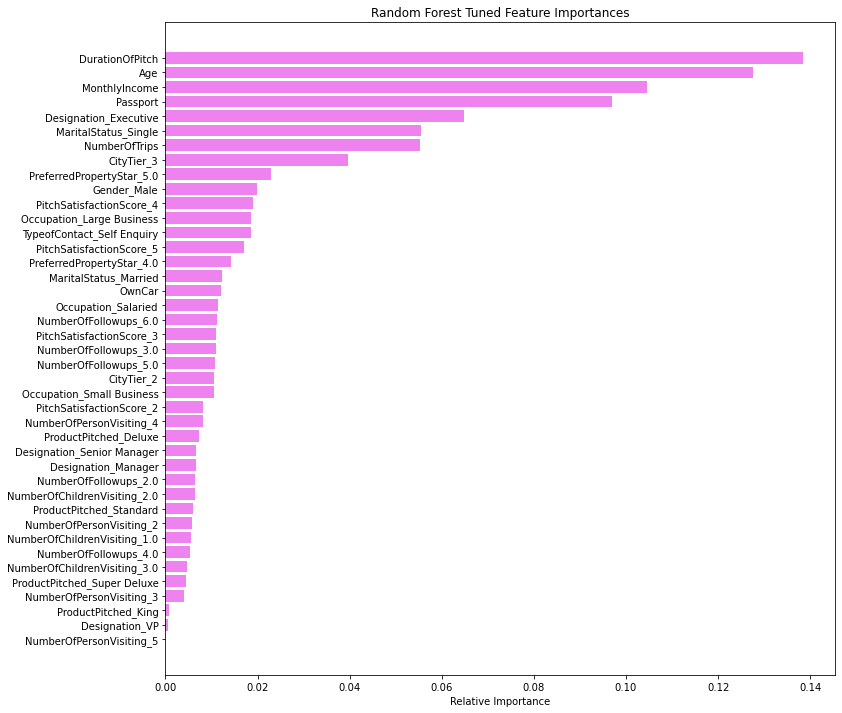

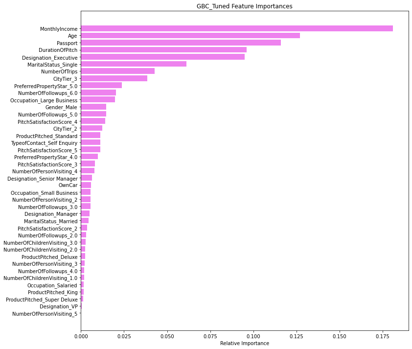

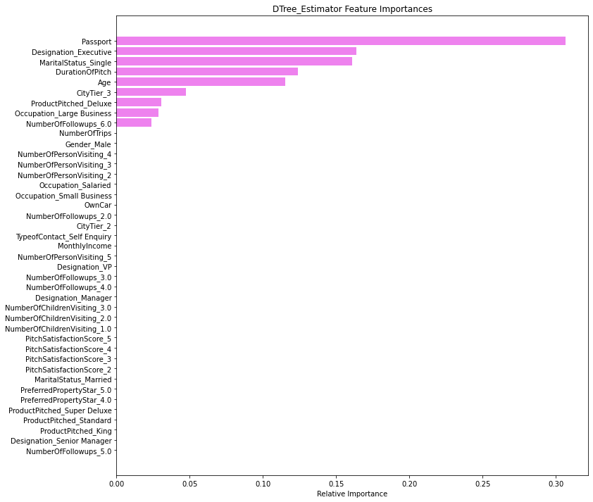

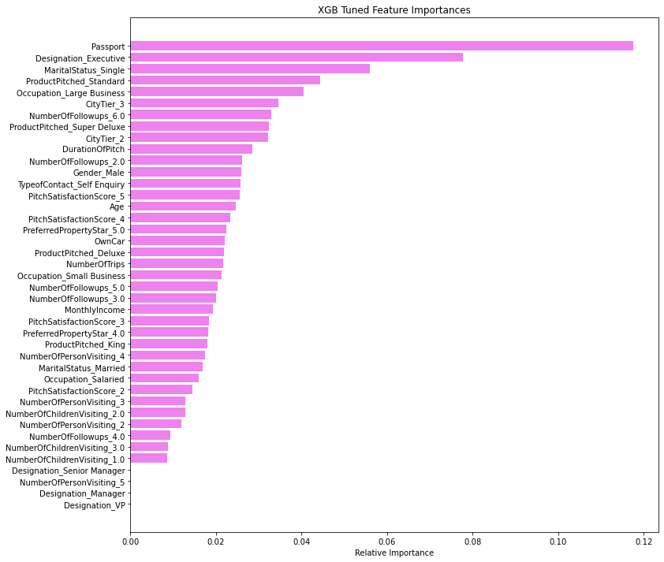

```python
#lets look at feature importance, The models used by Stacking Classifier were, rf_tuned, gbc_tuned, dtree_estimator
#and the final estimator is xgb_tuned. We can print feature importance for these models

importances = rf_tuned.feature_importances_
indices = np.argsort(importances)
plt.figure(figsize=(12,12))
plt.title('Random Forest Tuned Feature Importances')
plt.barh(range(len(indices)), importances[indices], color='violet', align='center')
plt.yticks(range(len(indices)), [feature_names[i] for i in indices])
plt.xlabel('Relative Importance')
plt.show()

importances = gbc_tuned.feature_importances_
indices = np.argsort(importances)
plt.figure(figsize=(12,12))
plt.title('GBC_Tuned Feature Importances')
plt.barh(range(len(indices)), importances[indices], color='violet', align='center')
plt.yticks(range(len(indices)), [feature_names[i] for i in indices])
plt.xlabel('Relative Importance')
plt.show()

importances = dtree_estimator.feature_importances_
indices = np.argsort(importances)
plt.figure(figsize=(12,12))
plt.title('DTree_Estimator Feature Importances')
plt.barh(range(len(indices)), importances[indices], color='violet', align='center')
plt.yticks(range(len(indices)), [feature_names[i] for i in indices])
plt.xlabel('Relative Importance')
plt.show()

importances = xgb_tuned.feature_importances_
indices = np.argsort(importances)
plt.figure(figsize=(12,12))
plt.title('XGB Tuned Feature Importances')
plt.barh(range(len(indices)), importances[indices], color='violet', align='center')
plt.yticks(range(len(indices)), [feature_names[i] for i in indices])
plt.xlabel('Relative Importance')
plt.show()
```

## Permutation Feature Importance

https://machinelearningmastery.com/calculate-feature-importance-with-python/

We can look at feature importance using Permutation. Permutation feature importance is a technique for calculating relative importance scores that is independent of the model used.We can use the Stacking_Classifier model and try to get feature importance.

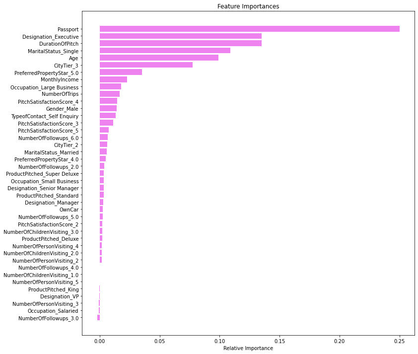

```python
#Update the value for the columns that have nulls to the median of train.
#This will be updated for the X data frame
X.loc[data['DurationOfPitch'].isnull(), 'DurationOfPitch'] = X_train['DurationOfPitch'].median()
X.loc[data['MonthlyIncome'].isnull(), 'MonthlyIncome'] = X_train['MonthlyIncome'].median()
X.loc[data['Age'].isnull(), 'Age'] = X_train['Age'].median()
X.loc[data['NumberOfTrips'].isnull(), 'NumberOfTrips'] = X_train['NumberOfTrips'].median()

from sklearn.neighbors import KNeighborsRegressor
from sklearn.inspection import permutation_importance
results = permutation_importance(stacking_classifier, X, Y, scoring='recall')
p_importance = results.importances_mean
indices = np.argsort(p_importance)
plt.figure(figsize=(12,12))
plt.title('Feature Importances')
plt.barh(range(len(indices)), p_importance[indices], color='violet', align='center')
plt.yticks(range(len(indices)), [feature_names[i] for i in indices])
plt.xlabel('Relative Importance')
plt.show()
```

Using Permutation Feature Importance and Stacking_classifier as the model we get the following feature importance. Passport, Designation_Executive, DurationOfPitch, MaritalStatus_Single, Age, and CityTier3, and it also included PreferredPropertyStar_5. The features are mostly consistent with one ones we saw with other models.

## Model Conclusions

Using Permutation Feature Importance and Stacking_classifier as the model we get the similar feature importance. The Permutation Feature Importance also included PreferredPropertyStar_5. The feautre importances were mostly consistent with one ones we saw with other models.

## Recommendations

The Business, "Visit with us", should give importance to customers who have a Passport. The models indicated that Passport is an important feature for predicting the customers who will buy a product. Also the bivariate analysis showed that customers who had a Passport bought a product as compared to customer who did not have a Passport.

The business should also look at customers who are Executives. the model showed that customers who had a Designation of Exceutive bought a product.

The business should look at the DurationOfPitch. The higher the duration the more likely that the customer will buy a product.

The customer should consider Age and MonthlyIncome of the customers. Also the bivariate anaysis showed a correlation between Age and MonthlyIncome.

The business should look at customers who live in CityTier3. The models showed that City Tier 3 is an important feature.

The business should consider the marital status of the customers. The models indicated that Single customers as an important feature.

The business can also look at Occupation. The model showed that Customers who work at Large businesses are more likely to buy a product.

The business should also look at the PreferredPropertyStar for their customers. Customers who had PreferredPropertyStar as 5 were more likely to buy a product.